# Logistic Regression

Deepika

March 13, 2019

```r
library(ISLR)
library(tidyverse)
library(skimr)
options(scipen = 777)

Default <- Default

#To get Information about the dataset
?Default
```

```
## starting httpd help server ...
```

```
##  done
```

```r
skim(Default)
```

```
## Skim summary statistics
##  n obs: 10000
##  n variables: 4
##
## -- Variable type:factor --------------------------------------------------------
##  variable missing complete     n n_unique                 top_counts
##   default       0    10000 10000        2  No: 9667, Yes: 333, NA: 0
##   student       0    10000 10000        2 No: 7056, Yes: 2944, NA: 0
##  ordered
##    FALSE
##    FALSE
##
## -- Variable type:numeric -------------------------------------------------------
##  variable missing complete     n     mean       sd     p0      p25
##   balance       0    10000 10000   835.37   483.71   0      481.73
##    income       0    10000 10000 33516.98 13336.64 771.97 21340.46
##       p50      p75     p100     hist
##    823.64  1166.31  2654.32 ▅▆▇▆▃▁▁▁
##  34552.64 43807.73 73554.23 ▁▆▆▆▇▅▁▁
```

```r
#Independent Variable Balance
log_reg <- glm(default ~ balance, family = "binomial", data = Default,  control = list(maxit = 50))
summary(log_reg)
```

```
##
## Call:
## glm(formula = default ~ balance, family = "binomial", data = Default,
##     control = list(maxit = 50))
##
## Deviance Residuals:
##     Min       1Q   Median       3Q      Max
## -2.2697  -0.1465  -0.0589  -0.0221   3.7589
##
## Coefficients:
##                Estimate  Std. Error z value            Pr(>|z|)
## (Intercept) -10.6513306   0.3611574  -29.49 <0.0000000000000002 ***
## balance       0.0054989   0.0002204   24.95 <0.0000000000000002 ***
## ---
## Signif. codes:  0 '***' 0.001 '**' 0.01 '*' 0.05 '.' 0.1 ' ' 1
##
## (Dispersion parameter for binomial family taken to be 1)
##
##     Null deviance: 2920.6  on 9999  degrees of freedom
## Residual deviance: 1596.5  on 9998  degrees of freedom
## AIC: 1600.5
##
## Number of Fisher Scoring iterations: 8
```

```r
##Prediction Using Coefficients

##Balance $1000 & $2000
predict(log_reg, newdata=data.frame(balance= c(1000,2000)),type = "response")
```

```
##           1           2
## 0.005752145 0.585769370
```

Deviance is a measure of goodness of fit of a model. Higher numbers always indicates bad fit.

Null Deviance, Null deviance shows how well the response is predicted by a model with nothing but an intercept (grand mean).

Residual deviance, When the model has included balance variable,then the residual deviance which is lower(1596.5) than null deviance(2920.6).Lower value of residual deviance points out that the model has become better when it has included balance variable.

AIC, Its full form is Akaike Information Criterion (AIC). This is useful when we have more than one model to compare the goodness of fit of the models.It is a maximum likelihood estimate which penalizes to prevent overfitting. It measures flexibility of the models. .Lower AIC of model is better than the model having higher AIC.

“Number of Fisher Scoring iterations” tells “how many iterations this algorithm run before it stopped”.Here it is 8.

```r
##Independent Variable Student
log_reg1 <- glm(default ~ student, family = "binomial",data = Default)
summary(log_reg1)
```

```
##
## Call:
## glm(formula = default ~ student, family = "binomial", data = Default)
##
## Deviance Residuals:
##     Min       1Q   Median       3Q      Max
## -0.2970  -0.2970  -0.2434  -0.2434   2.6585
##
## Coefficients:
##             Estimate Std. Error z value             Pr(>|z|)
## (Intercept) -3.50413    0.07071  -49.55 < 0.0000000000000002 ***
## studentYes   0.40489    0.11502    3.52             0.000431 ***
## ---
## Signif. codes:  0 '***' 0.001 '**' 0.01 '*' 0.05 '.' 0.1 ' ' 1
##
## (Dispersion parameter for binomial family taken to be 1)
##
##     Null deviance: 2920.6  on 9999  degrees of freedom
## Residual deviance: 2908.7  on 9998  degrees of freedom
## AIC: 2912.7
##
## Number of Fisher Scoring iterations: 6
```

```r
##Predictions
predict(log_reg1, newdata=data.frame(student = c("Yes","No")),type = "response")
```

```
##          1          2
## 0.04313859 0.02919501
```

```r
#Logistic regression with several variables
Logistic_regression_model <- glm(default ~. , family = "binomial", data = Default)
summary(Logistic_regression_model)
```

```
##
## Call:
## glm(formula = default ~ ., family = "binomial", data = Default)
##
## Deviance Residuals:
##     Min       1Q   Median       3Q      Max
## -2.4691  -0.1418  -0.0557  -0.0203   3.7383
##
## Coefficients:
##                  Estimate    Std. Error z value             Pr(>|z|)
## (Intercept) -10.869045196   0.492255516 -22.080 < 0.0000000000000002 ***
## studentYes   -0.646775807   0.236252529  -2.738              0.00619 **
## balance       0.005736505   0.000231895  24.738 < 0.0000000000000002 ***
## income        0.000003033   0.000008203   0.370              0.71152
## ---
## Signif. codes:  0 '***' 0.001 '**' 0.01 '*' 0.05 '.' 0.1 ' ' 1
##
## (Dispersion parameter for binomial family taken to be 1)
##
##     Null deviance: 2920.6  on 9999  degrees of freedom
## Residual deviance: 1571.5  on 9996  degrees of freedom
## AIC: 1579.5
##
## Number of Fisher Scoring iterations: 8
```

```r
Logistic_regression_model1 <- glm(default~ .-income, family = "binomial",data = Default)
summary(Logistic_regression_model1)
```

```
##
## Call:
## glm(formula = default ~ . - income, family = "binomial", data = Default)
##
## Deviance Residuals:
##     Min       1Q   Median       3Q      Max
## -2.4578  -0.1422  -0.0559  -0.0203   3.7435
##
## Coefficients:
##                Estimate  Std. Error z value             Pr(>|z|)
## (Intercept) -10.7494959   0.3691914 -29.116 < 0.0000000000000002 ***
## studentYes   -0.7148776   0.1475190  -4.846           0.00000126 ***
## balance       0.0057381   0.0002318  24.750 < 0.0000000000000002 ***
## ---
## Signif. codes:  0 '***' 0.001 '**' 0.01 '*' 0.05 '.' 0.1 ' ' 1
##
## (Dispersion parameter for binomial family taken to be 1)
##
##     Null deviance: 2920.6  on 9999  degrees of freedom
## Residual deviance: 1571.7  on 9997  degrees of freedom
## AIC: 1577.7
##
## Number of Fisher Scoring iterations: 8
```

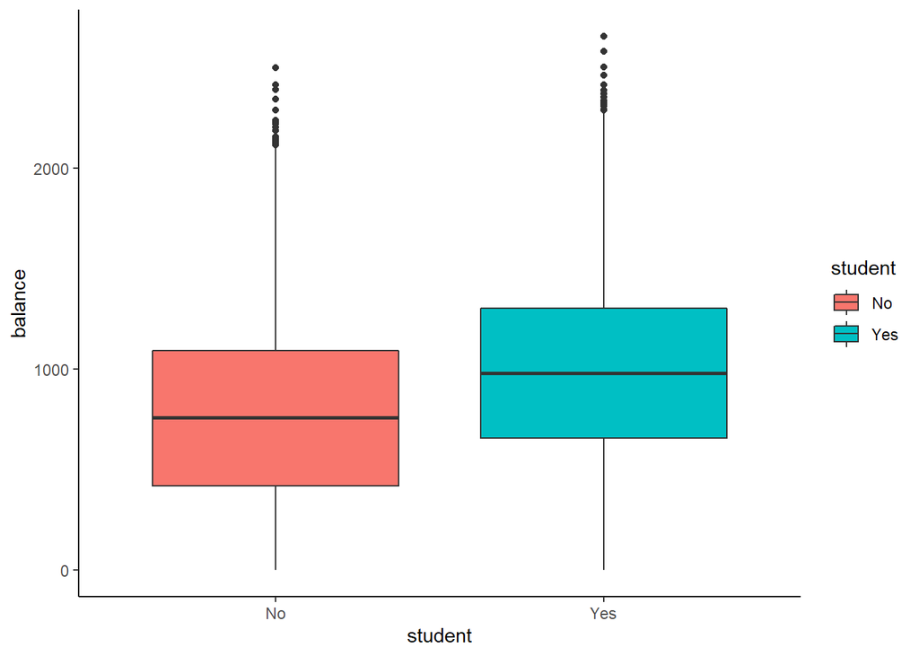

```r
#Confonding

##Relationship between Student and balance Variable

ggplot(data = Default,mapping = aes(x=student,y=balance,fill=student))+geom_boxplot()+theme_classic()
```

```r
t.test(Default[Default$student=="Yes",]$balance,Default[Default$student=="No",]$balance)
```

```
##
##  Welch Two Sample t-test
##
## data:  Default[Default$student == "Yes", ]$balance and Default[Default$student == "No", ]$balance
## t = 20.555, df = 5375.2, p-value < 0.00000000000000022
## alternative hypothesis: true difference in means is not equal to 0
## 95 percent confidence interval:
##  195.4425 236.6532
## sample estimates:
## mean of x mean of y
##  987.8182  771.7704
```

Hypothesis Testing: Is mean balance of student Vs Non-student is different or not

```r
#Using model without variable Income
Default$Predicted <- predict(Logistic_regression_model1,type = "response")
Default$Predicted_res <- ifelse(Default$Predicted>0.50,1,0)
Default$default <- ifelse(Default$default=="Yes",1,0)


##Confusion Matrix
table(Default$default,Default$Predicted_res)
```

```
##
##        0    1
##   0 9628   39
##   1  228  105
```

```r
library(caret)
confusionMatrix(table(Default$default,Default$Predicted_res))
```

```
## Confusion Matrix and Statistics
##
##
##        0    1
##   0 9628   39
##   1  228  105
##
##                Accuracy : 0.9733
##                  95% CI : (0.9699, 0.9764)
##     No Information Rate : 0.9856
##     P-Value [Acc > NIR] : 1
##
##                   Kappa : 0.4288
##  Mcnemar's Test P-Value : <0.0000000000000002
##
##             Sensitivity : 0.9769
##             Specificity : 0.7292
##          Pos Pred Value : 0.9960
##          Neg Pred Value : 0.3153
##              Prevalence : 0.9856
##          Detection Rate : 0.9628
##    Detection Prevalence : 0.9667
##       Balanced Accuracy : 0.8530
##
##        'Positive' Class : 0
##
```

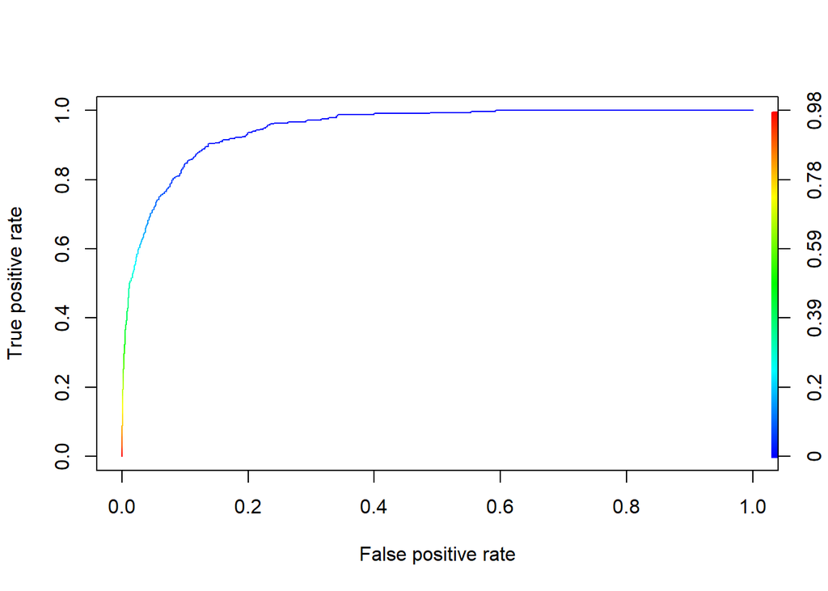

```r
##ROC Curve

library(ROCR)
ROCRPred = prediction(Default$Predicted,Default$default)
ROCRPredf <- performance(ROCRPred,"tpr","fpr")

##plot
plot(ROCRPredf,colorize=TRUE,print.cutoff.at=seq(0.1,by=0.1))
```